# Mutated Genes - Comprehensive Analysis

Hilmar Berger

28 November, 2019 14:03:41

```r
rm(list=ls())
library(data.table)
library(ggplot2)
library(pheatmap)
library(GenomicFeatures)
library(xlsx)
library(org.Mm.eg.db)
library(knitr)

result_folder = "../../../Results/DNASeq"
if (!file.exists(result_folder)) dir.create(result_folder, recursive=T)
```

# 1 Data

We here will try to combined the following types of data from both mice analysed in the experiment:

- SNV/InDel calls from Strelka
- CNV gain/loss calls from CONTRA
- RNA Expression levels in uninfected controls from mouse 1 (not analysed with Exome sequencing)

```r
#SNV/Indels
strelka_single_env = new.env()
load("../SNV_Strelka/Colibactin_Exome_Strelka_Calls_both_mice.Rdata", envir=strelka_single_env)
strelka_single_variants = strelka_single_env[["all_variants"]]
strelka_single_variants_anno = strelka_single_env[["anno_unique_sites_highest_impact"]]
strelka_single_variants_anno[, varID := paste(CHROM,":",POS,"_",REF,"/",ALT,sep="")]

# # Variants called after aggregating samples
# strelka_aggregated_env = new.env()
# load("../Strelka_aggregated/Colibactin_Exome_Strelka_Calls_both_mice.Rdata", envir=strelka_aggregated_env)
# strelka_aggregated_variants = strelka_aggregated_env[["all_variants"]]
# strelka_aggregated_variants_anno = strelka_aggregated_env[["anno_unique_sites_highest_impact"]]
# strelka_aggregated_variants_anno[, varID := paste(CHROM,":",POS,"_",REF,"/",ALT,sep="")]
#
#strelka_anno_combined = rbind(strelka_single_variants_anno, strelka_aggregated_variants_anno)
strelka_anno_combined = strelka_single_variants_anno
strelka_anno_combined = strelka_anno_combined[!duplicated(varID)]

cnv_env = new.env()
load(file.path(result_folder, "CN_calls.Rdata"), envir=cnv_env)

cnv_dt = cnv_env[["all_long_CN_calls_dt"]]
gcounts = elementNROWS(cnv_dt$EnsemblGene)
cnv_anno_ensg = with(cnv_dt, data.table(sampleID=rep(sample, gcounts), varID=rep(varID, gcounts), chrom=rep(chrom, gcounts), start=rep(loc.start, gcounts), end=rep(loc.end, gcounts), seg.mean=rep(seg.mean, gcounts), call=rep(call, gcounts), ensgene = unlist(EnsemblGene)   ) )

ge_env = new.env()
load("../../../Data/Processed/RNA_counts/Salmon_gene_expression_estimates_controls.Rdata", envir=ge_env)

ed = read.xlsx("../../../Data/Metadata/DNA/SampleDescription.xls", sheetIndex = 1, stringsAsFactors=F)
rownames(ed) = ed$SampleID
```

```r
ge_levels = ge_env[["gene_expression_estimates_controls"]]
rownames(ge_levels) = ge_levels$ENSG
expressed_genes = ge_levels[(ge_levels$TPM_E>0.1 | ge_levels$TMP_F > 0.1), "ENSG"]
ge_levels$gene_means = apply(ge_levels[,c("TPM_E","TMP_F")], 1, mean, na.rm=T)

gene_means_expressed = ge_levels[expressed_genes, ]$gene_means
qq = quantile(gene_means_expressed, p=c(0,0.25,0.5,0.75, 1))
ge_levels$ge_quartile="Not expressed"
ge_levels[expressed_genes,]$ge_quartile = cut(ge_levels[expressed_genes,]$gene_means, breaks = qq, labels = c("Q4", "Q3", "Q2", "Q1"))

ge_levels$ge_rank = nrow(ge_levels) - rank(ge_levels$gene_means) + 1
```

```r
M17db = loadDb("../../../Data/External/GencodeM17/GENCODE_basic_M17_TxDB.db")
tx_anno = fread("../../../Data/External/GencodeM17/gencode.vM17.transcript.anno.txt", sep="\t", header=T, stringsAsFactors = F)
setkey(tx_anno, transcript)

gs_to_ensg = tx_anno[, .(ENSG=unique(gene)[1]), by="GeneSymbol"]
gs_to_ensg[,n:=elementNROWS(ENSG), by="GeneSymbol"]
setkey(gs_to_ensg, "GeneSymbol")

ensg_to_gs = tx_anno[, .(GeneSymbol_list=list(unique(GeneSymbol))), by="gene"]
ensg_to_gs[,n:=elementNROWS(GeneSymbol_list), by="gene"]
ensg_to_gs[, geneid_fixed := sapply(strsplit(gene,"\\."), function(x) x[1])]
ensg_to_gs[, GeneSymbol := lapply(GeneSymbol_list, paste, collapse=",")]
setkey(ensg_to_gs, "geneid_fixed")

tx_anno[, geneid_fixed:= sapply(strsplit(gene,"\\."), function(x) x[1])]
gene_anno = tx_anno[, .(protein_coding_or_functional=any(TxType %in% c("protein_coding", "rRNA","lincRNA","miRNA","Mt_rRNA","Mt_tRNA"))), by=c("geneid_fixed","GeneSymbol")]
setkey(gene_anno, "geneid_fixed")


gene_ranges = sort(genes(M17db))
```

```r
all_genes = data.table(geneid=gene_ranges$gene_id)
all_genes[, geneid_fixed := sapply(strsplit(geneid,"\\."), function(x) x[1])]
setkey(all_genes, "geneid")

wi_samples = subset(ed, Condition =="Wnt-independent")$SampleID
control_samples = subset(ed, Condition =="Uninfected")$SampleID

# cnv_ranges = with(cnv_segments, GRanges(chrom, IRanges(start, end), sampleID=sampleID, index=1:nrow(cnv_segments)))
#
# strelka_anno_ranges = with(strelka_anno_combined, GRanges(CHROM, IRanges(POS,POS), index=1:nrow(strelka_anno_combined)))

all_tabs = list()
for (s in sort(c(wi_samples, control_samples))) {
  curr_gene_tab = all_genes
  cnv_tmp = subset(cnv_anno_ensg, sampleID==s)
  if (nrow(cnv_tmp)>0) {
    curr_gene_tab = merge(curr_gene_tab, cnv_tmp, by.x="geneid", by.y="ensgene", all.x=T)
  } else {
    #empty_tab = matrix(rep(as.character(NA), length(colnames(cnv_anno_ensg))), ncol=ncol(cnv_anno_ensg), nrow=1)
    #colnames(empty_tab) = colnames(cnv_anno_ensg)
    #empty_tab_dt = as.data.table(empty_tab)
     empty_tab = data.table(sampleID=NA_character_, varID=NA_character_, chrom=NA_character_, start=NA_integer_, end=NA_integer_, seg.mean=NA_real_, call = NA_character_, ensgene = NA_character_ )
    curr_gene_tab = merge(curr_gene_tab, empty_tab, by.x="geneid", by.y="ensgene", all.x=T)
  }
  snv_tmp = subset(strelka_single_variants, sampleID==s)
  if (length(snv_tmp)>0) {
    snv_tmp_dt = data.table(chrom=as.character(seqnames(snv_tmp)), start=start(snv_tmp), end=end(snv_tmp))
    snv_tmp_dt = cbind(snv_tmp_dt, as.data.table(mcols(snv_tmp)))
    snv_tmp_dt$ALT = unstrsplit(CharacterList(snv_tmp_dt$ALT), sep = ",")
    snv_tmp_dt$varID = names(snv_tmp)

    snv_tmp_dt = merge(snv_tmp_dt, strelka_anno_combined, by.x="varID", by.y="varID", all.x=T)

    gcounts = elementNROWS(snv_tmp_dt$ENSG)
    snv_ts = with(snv_tmp_dt, data.table(sampleID=rep(sampleID, gcounts), varID=rep(varID, gcounts), chrom=rep(chrom, gcounts), start=rep(start, gcounts), end=rep(end, gcounts), ensgene = unlist(ENSG), HighestImpact = rep(HighestImpact, gcounts), AnnotationType = unlist(AnnotationType)   ) )
    # a few ensgene IDs do not match the M17 list of genes. Most of those are abandonded ENSG IDs or strange fusion IDs
    curr_gene_tab = merge(curr_gene_tab, snv_ts, by.x="geneid_fixed", by.y="ensgene", all.x=T)
  } else {
    empty_tab = data.table(sampleID=NA_character_, varID=NA_character_, chrom=NA_character_, start=NA_integer_, end=NA_integer_, ensgene = NA_character_, HighestImpact = NA_character_, AnnotationType = NA_character_   )
    curr_gene_tab = merge(curr_gene_tab, empty_tab, by.x="geneid_fixed", by.y="ensgene", all.x=T)
  }

  curr_gene_tab = merge(curr_gene_tab, ge_levels[, c("ENSG","gene_means", "ge_quartile","ge_rank")], by.x="geneid_fixed", by.y="ENSG", all.x=T, sort=F)
  curr_gene_tab_filtered = subset(curr_gene_tab, !(is.na(sampleID.x) & is.na(sampleID.y)) )
  curr_gene_tab_filtered[, sampleID := ifelse(!is.na(sampleID.x), sampleID.x, sampleID.y )]
  curr_gene_tab_filtered[, mutationType:= ifelse(!is.na(sampleID.x) & !is.na(sampleID.y), "SNV/CNV", ifelse(is.na(sampleID.x), "SNV only", "CNV only")) ]
  curr_gene_tab_filtered[["sampleID.x"]] <- NULL
  curr_gene_tab_filtered[["sampleID.y"]] <- NULL


  if(nrow(curr_gene_tab_filtered)>0) {
    all_tabs[[s]] = curr_gene_tab_filtered
  }
}

all_variants_combined = do.call(rbind, all_tabs)
setnames(all_variants_combined, colnames(all_variants_combined), gsub("\\.y$",".SNV",gsub("\\.x$",".CNV",colnames(all_variants_combined))))

all_variants_combined[,GeneSymbol := unlist(lapply(ensg_to_gs[geneid_fixed]$GeneSymbol, paste,collapse=","))]

all_variants_combined[, gene_chr := as.character(seqnames(gene_ranges[geneid]))]
all_variants_combined[, gene_start := as.character(start(gene_ranges[geneid]))]

all_variants_combined[, functional_tx:=gene_anno[geneid_fixed]$protein_coding_or_functional]

setkey(all_variants_combined,"geneid_fixed")
```

# 2 All variants - overview

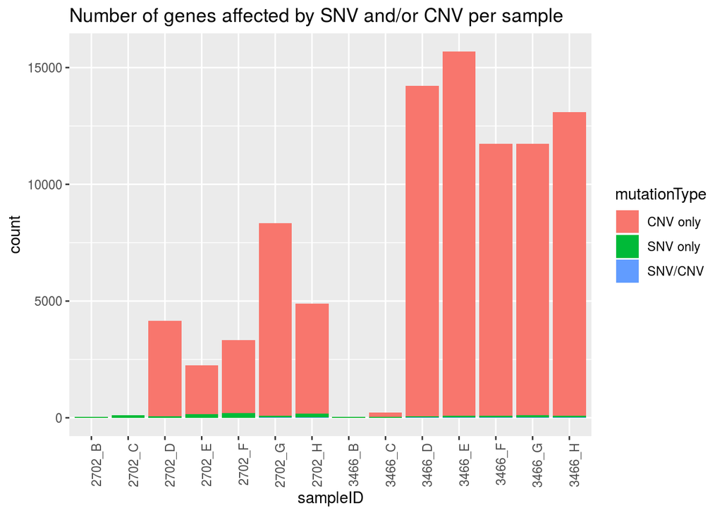

```r
ggplot(all_variants_combined, aes(x=sampleID, fill=mutationType)) + geom_bar() + ggtitle("Number of genes affected by SNV and/or CNV per sample") + theme(axis.text.x = element_text(angle = 90, hjust = 1))
```

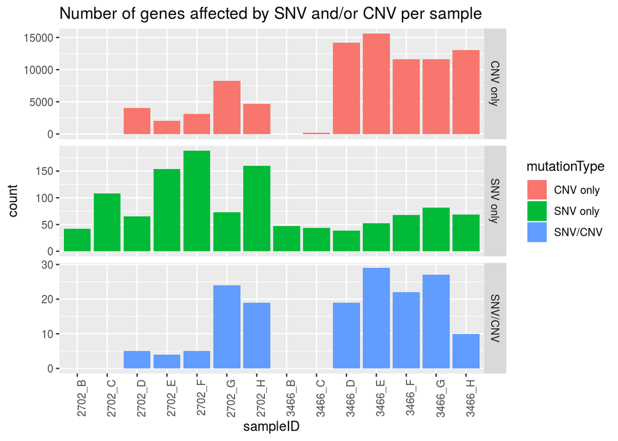

```r
ggplot(all_variants_combined, aes(x=sampleID, fill=mutationType)) + geom_bar() + ggtitle("Number of genes affected by SNV and/or CNV per sample") + theme(axis.text.x = element_text(angle = 90, hjust = 1)) + facet_grid(mutationType~., scales="free_y")
```

```r
with(all_variants_combined, ftable(sampleID, mutationType ))
```

```
##          mutationType CNV only SNV only SNV/CNV
## sampleID
## 2702_B                       0       42       0
## 2702_C                       0      108       0
## 2702_D                    4083       65       5
## 2702_E                    2080      154       4
## 2702_F                    3125      188       5
## 2702_G                    8248       73      24
## 2702_H                    4702      160      19
## 3466_B                       0       47       0
## 3466_C                     179       44       0
## 3466_D                   14168       39      19
## 3466_E                   15600       52      29
## 3466_F                   11639       68      22
## 3466_G                   11634       82      27
## 3466_H                   13010       69      10
```

```r
gene_vars_by_sample = dcast.data.table(all_variants_combined, geneid_fixed ~ sampleID, fun.aggregate = length, value.var="mutationType")

sample_class = factor(ed[colnames(gene_vars_by_sample)[2:ncol(gene_vars_by_sample)],]$Condition)
sample_mouse = factor(ed[colnames(gene_vars_by_sample)[2:ncol(gene_vars_by_sample)],]$MouseID)

mut_counts_by_condition = as.data.frame(t(apply(gene_vars_by_sample[,2:ncol(gene_vars_by_sample), with=F], 1, function(x) tapply(x, sample_class, sum ))))
rownames(mut_counts_by_condition) = gene_vars_by_sample$geneid_fixed

# mut_counts_by_mouse = as.data.frame(t(apply(gene_vars_by_sample[,2:ncol(gene_vars_by_sample), with=F], 1, function(x) tapply(x, sample_mouse, sum ))))
# rownames(mut_counts_by_mouse) = gene_vars_by_sample$geneid_fixed

mut_counts_by_class_and_mouse = as.data.frame(t(apply(gene_vars_by_sample[,2:ncol(gene_vars_by_sample), with=F], 1, function(x) tapply(x, paste(sample_class, sample_mouse), sum ))))
rownames(mut_counts_by_class_and_mouse) = gene_vars_by_sample$geneid_fixed

genes_mutated_only_WI = rownames(mut_counts_by_condition)[mut_counts_by_condition$Uninfected==0 & mut_counts_by_condition$"Wnt-independent" >0]
genes_mutated_WI_both_mice = rownames(mut_counts_by_class_and_mouse)[mut_counts_by_class_and_mouse$`Wnt-independent 2`>0 & mut_counts_by_class_and_mouse$`Wnt-independent 3`>0 ]

all_variants_combined[, mutated_only_WI:= rep(FALSE, nrow(all_variants_combined))]
all_variants_combined[genes_mutated_only_WI, mutated_only_WI:= TRUE]

all_variants_combined[, mutated_WI_both_mice:= rep(FALSE, nrow(all_variants_combined))]
all_variants_combined[genes_mutated_WI_both_mice, mutated_WI_both_mice:= TRUE]
```

```r
unique(all_variants_combined[, c("geneid_fixed","mutated_only_WI", "mutated_WI_both_mice")])[, .N, by=c("mutated_only_WI", "mutated_WI_both_mice")]
```

```
##    mutated_only_WI mutated_WI_both_mice     N
## 1:            TRUE                FALSE 11311
## 2:            TRUE                 TRUE  7347
## 3:           FALSE                 TRUE    43
## 4:           FALSE                FALSE   318
```

# 3 Known Wnt-Pathway genes

```r
homologene_human_mouse = fread("../../../Data/External/homologene_9606_10090.txt")
all_ensg = unique(all_variants_combined$geneid_fixed)
entrezid = unique(select(org.Mm.eg.db, keys=all_ensg, keytype = "ENSEMBL", columns="ENTREZID"))
entrezid$ENTREZID = as.integer(entrezid$ENTREZID)
entrezid = subset(entrezid, !is.na(ENTREZID))

mouse_to_human = merge(entrezid, homologene_human_mouse[!is.na(homologene_human_mouse$entrez_2),c("entrez_1","entrez_2","symbol_1","symbol_2"), with=F], by.x="ENTREZID", by.y="entrez_2", all.x=T, sort=F)
```

```r
wnt_reactome_genes = read.table("../../../Data/External/GeneSets/WNT_Participating Molecules [R-HSA-195721].tsv", sep="\t", header=T)
library(org.Hs.eg.db)
wnt_proteins = as.character(subset(wnt_reactome_genes, MoleculeType=="Proteins")$Identifier)
reactome_wnt_symbol = select(org.Hs.eg.db, keys=wnt_proteins, keytype="UNIPROT", columns="SYMBOL" )$SYMBOL
reactome_wnt_mouse_ensg = subset(mouse_to_human, !is.na(symbol_1) & symbol_1 %in% reactome_wnt_symbol)$ENSEMBL


kegg_genes = read.table("../../../Data/External/GeneSets/KEGG_WNT_PATHWAY.txt", sep="\t", header=T)

kegg_wnt_symbol = select(org.Hs.eg.db, keys=as.character(kegg_genes$EntrezID), keytype="ENTREZID", columns="SYMBOL" )$SYMBOL
kegg_wnt_mouse_ensg = subset(mouse_to_human, !is.na(symbol_1) & symbol_1 %in% kegg_wnt_symbol)$ENSEMBL

kegg_p53_pathway = read.table("../../../Data/External/GeneSets/KEGG_TP53_MSIGv7.0.txt", sep="\t", header=T, stringsAsFactors = F)
p53_entrez = kegg_p53_pathway$Entrez.Gene.Id
p53_entrez = p53_entrez[!is.na(p53_entrez)]

kegg_p53_mouse_ensg = subset(mouse_to_human, !is.na(symbol_1) & entrez_1 %in% p53_entrez)$ENSEMBL
```

There are 297 Wnt-pathway associated proteins in Reactome DB out of which 137 Ensembl-Gene-IDs for homologous mouse genes.

There are 146 Wnt-pathway associated proteins in KEGG DB out of which 53 Ensembl-Gene-IDs for homologous mouse genes could be mapped.

There are 69 p53-pathway associated proteins in KEGG DB out of which 24 Ensembl-Gene-IDs for homologous mouse genes could be mapped.

Files with Wnt-pathway genes that have CNV or SNV are written to separater files for KEGG and Reactome genes.

## 3.1 KEGG

Number of genes from the KEGG Wnt-Pathway with mutation only in Wnt-independent clones:

```r
sum(kegg_wnt_mouse_ensg %in% all_variants_combined[mutated_only_WI==TRUE]$geneid_fixed)
```

```
## [1] 52
```

```r
all_variants_combined$KEGG_WNT = all_variants_combined$geneid_fixed %in% kegg_wnt_mouse_ensg


aa = all_variants_combined[mutated_only_WI==TRUE & geneid_fixed %in% kegg_wnt_mouse_ensg]

write.table(aa, file="KEGG_WNT_genes_with_variants.txt", sep="\t", row.names=F, quote=F)
```

## 3.2 Reactome

Number of genes from the Reactome Wnt-Pathway with mutation only in Wnt-independent clones:

```r
sum(reactome_wnt_mouse_ensg %in% all_variants_combined[mutated_only_WI==TRUE]$geneid_fixed)
```

```
## [1] 135
```

```r
all_variants_combined$Reactome_WNT = all_variants_combined$geneid_fixed %in% reactome_wnt_mouse_ensg

aa = all_variants_combined[mutated_only_WI==TRUE & geneid_fixed %in% reactome_wnt_mouse_ensg]

write.table(aa, file="REACTOME_WNT_genes_with_variants.txt", sep="\t", row.names=F, quote=F)
```

## 3.3 P53 pathway genes

```r
sum(kegg_p53_mouse_ensg %in% unique(all_variants_combined[mutated_only_WI==TRUE]$geneid_fixed))
```

```
## [1] 24
```

```r
all_variants_combined$KEGG_P53 = all_variants_combined$geneid_fixed %in% kegg_p53_mouse_ensg
```

## 3.4 Pan-Cancer driver genes

We here use a list of pan-cancer driver genes from the TCGA PanCancer consortium, published in 2018 (Bailey et al. Cell. 2018 Apr 5;173(2):371-385.e18. doi: 10.1016/j.cell.2018.02.060.)

```r
pan_cancer_drivers = read.table("../../../Data/External/GeneSets/PanCancerDriverGenes_TCGA_2018.txt.csv", sep="\t", header=T, comment.char="", na.strings = c("NA","#N/A"), stringsAsFactors = F )

colnames(pan_cancer_drivers)[4] = "Tumor.suppressor.or.oncogene.prediction"

pan_cancer_drivers_to_mouse = merge(pan_cancer_drivers, mouse_to_human, by.x="Gene", by.y="symbol_1", sort=F)
pan_cancer_drivers_mouse_dt = as.data.table(pan_cancer_drivers_to_mouse)

tmp = pan_cancer_drivers_mouse_dt[, .(cancer=paste(Cancer, collapse=",")) , by=c("Gene","ENSEMBL", "Tumor.suppressor.or.oncogene.prediction")]
pan_cancer_drivers_mouse_dt_short = tmp[, .(TCGA_PanCancer_prediction=paste(paste(cancer, Tumor.suppressor.or.oncogene.prediction, sep=":") , collapse="|")), by=c("Gene","ENSEMBL")]
setkey(pan_cancer_drivers_mouse_dt_short, "ENSEMBL")

all_variants_combined[, `:=`(pan_cancer_driver=ifelse(geneid_fixed %in% pan_cancer_drivers_mouse_dt_short$ENSEMBL, T, F), TCGA_PanCancer_prediction=pan_cancer_drivers_mouse_dt_short[geneid_fixed]$TCGA_PanCancer_prediction)]

#tmp2 = all_variants_combined[mutated_only_WI==TRUE]
#aa = merge(tmp2, pan_cancer_drivers_mouse_dt_short, by.x="geneid_fixed", by.y="ENSEMBL")

#write.table(aa, file="TCGA_PanCancer_Driver_genes_with_variants.txt", sep="\t", row.names=F, quote=F)
```

```r
write.table(all_variants_combined[mutated_only_WI==TRUE], file=file.path(result_folder, "all_variants_mutated_only_in_WI.txt"), sep="\t", row.names=F, quote=F)
```

```r
save(all_variants_combined, file=file.path(result_folder, "All_variants_combined_annotated.Rdata"))
```

# 4 Filtered Variants

We filter out SNV variants found in WI and NI and those SNV with LOW or MODIFIER impact level, keeping only HIGH and MODERATE levels as defined by SnpEff (http://snpeff.sourceforge.net/SnpEff_manual.html#input).

```r
all_variants_combined_filtered = all_variants_combined[mutated_only_WI==TRUE & (is.na(HighestImpact) | (!is.na(HighestImpact) & HighestImpact %in% c("HIGH","MODERATE")))]

all_variants_combined_filtered[, MouseID:= ed[sampleID,]$MouseID]

all_variants_combined_filtered$mutationType2 = ifelse(all_variants_combined_filtered$mutationType=="SNV/CNV", "SNV & CNV", all_variants_combined_filtered$mutationType)

ed$sample_name_short = with(ed, paste0(Sample.Name, " Mouse ",MouseID))

lvls = ed[order(ed$MouseID, ed$Sample.Name),]$sample_name_short
ed$sample_name_short = factor(ed$sample_name_short, lvls)

all_variants_combined_filtered$sample_name = ed[all_variants_combined_filtered$sampleID,]$sample_name_short
```

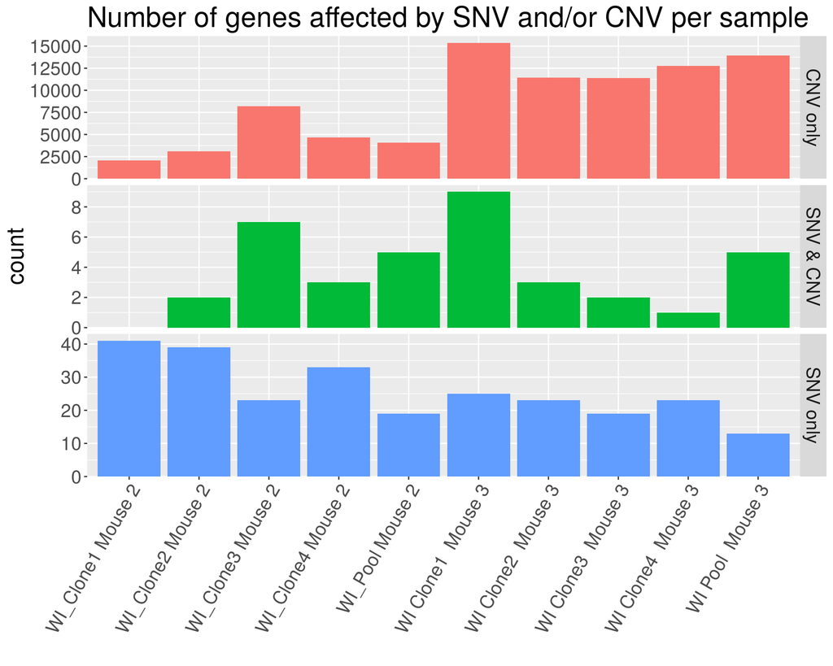

```r
break_fun = function(x) {
  b = ceiling(x[1])
  t = floor(x[2])
  if(t < 100) {
    bb=seq(b, t, by = floor((t-b)/4))
  } else {
    bb=seq(b, t, by = (10**(round(log10(t)) ) )/4)
  }
  return(bb)
}

p = ggplot(all_variants_combined_filtered, aes(x=sample_name, fill=mutationType2)) +
  geom_bar() +
  #ggtitle("Number of genes affected by SNV and/or CNV per sample") +
  theme(axis.text.x = element_text(angle = 60, hjust = 1), text=element_text(size=20)) +
  facet_grid(mutationType2~., scales="free_y") +
  scale_y_continuous(
    breaks = break_fun,
    expand = expand_scale(mult = c(0, 0.05))
    ) +
  theme(legend.position="none") +
  xlab("")
p + ggtitle("Number of genes affected by SNV and/or CNV per sample")
```

```r
cairo_pdf(file=file.path(result_folder, "CNV_SNV_affected_genes.pdf"), width=8, height=8)
print(p)
dev.off()
```

## 4.1 Mutations per Sample

### 4.1.1 All (filtered) mutations

```r
with(all_variants_combined_filtered, ftable(sampleID, mutationType  ))
```

```
##          mutationType CNV only SNV only SNV/CNV
## sampleID
## 2702_D                    4066       19       5
## 2702_E                    2070       41       0
## 2702_F                    3116       39       2
## 2702_G                    8219       23       7
## 2702_H                    4682       33       3
## 3466_D                   13938       13       5
## 3466_E                   15365       25       9
## 3466_F                   11411       23       3
## 3466_G                   11408       19       2
## 3466_H                   12782       23       1
```

### 4.1.2 All Pan-cancer drivers

```r
with(all_variants_combined_filtered, ftable(sampleID, mutationType, pan_cancer_driver  ))
```

```
##                       pan_cancer_driver FALSE  TRUE
## sampleID mutationType
## 2702_D   CNV only                        4047    19
##          SNV only                          19     0
##          SNV/CNV                            5     0
## 2702_E   CNV only                        2056    14
##          SNV only                          40     1
##          SNV/CNV                            0     0
## 2702_F   CNV only                        3104    12
##          SNV only                          39     0
##          SNV/CNV                            2     0
## 2702_G   CNV only                        8179    40
##          SNV only                          23     0
##          SNV/CNV                            7     0
## 2702_H   CNV only                        4657    25
##          SNV only                          32     1
##          SNV/CNV                            3     0
## 3466_D   CNV only                       13865    73
##          SNV only                          13     0
##          SNV/CNV                            5     0
## 3466_E   CNV only                       15274    91
##          SNV only                          25     0
##          SNV/CNV                            9     0
## 3466_F   CNV only                       11349    62
##          SNV only                          23     0
##          SNV/CNV                            3     0
## 3466_G   CNV only                       11346    62
##          SNV only                          18     1
##          SNV/CNV                            2     0
## 3466_H   CNV only                       12712    70
##          SNV only                          22     1
##          SNV/CNV                            1     0
```

### 4.1.3 All WNT-pathway genes

```r
with(all_variants_combined_filtered, ftable(sampleID, mutationType, (Reactome_WNT | KEGG_WNT)  , dnn=c("Sample ID", "Mutation Type", " WNT gene")))
```

```
##                          WNT gene FALSE  TRUE
## Sample ID Mutation Type
## 2702_D    CNV only                 4006    60
##           SNV only                   18     1
##           SNV/CNV                     4     1
## 2702_E    CNV only                 2063     7
##           SNV only                   39     2
##           SNV/CNV                     0     0
## 2702_F    CNV only                 3066    50
##           SNV only                   38     1
##           SNV/CNV                     2     0
## 2702_G    CNV only                 8136    83
##           SNV only                   22     1
##           SNV/CNV                     7     0
## 2702_H    CNV only                 4659    23
##           SNV only                   32     1
##           SNV/CNV                     3     0
## 3466_D    CNV only                13806   132
##           SNV only                   13     0
##           SNV/CNV                     5     0
## 3466_E    CNV only                15233   132
##           SNV only                   25     0
##           SNV/CNV                     9     0
## 3466_F    CNV only                11296   115
##           SNV only                   23     0
##           SNV/CNV                     3     0
## 3466_G    CNV only                11292   116
##           SNV only                   19     0
##           SNV/CNV                     2     0
## 3466_H    CNV only                12659   123
##           SNV only                   23     0
##           SNV/CNV                     1     0
```

### 4.1.4 All Pan-cancer drivers and WNT-pathway genes

```r
with(all_variants_combined_filtered, ftable(sampleID, mutationType, pan_cancer_driver & (Reactome_WNT | KEGG_WNT)  , dnn=c("Sample ID", "Mutation Type", "Pan-cancer driver & WNT gene")))
```

```
##                         Pan-cancer driver & WNT gene FALSE  TRUE
## Sample ID Mutation Type
## 2702_D    CNV only                                    4066     0
##           SNV only                                      19     0
##           SNV/CNV                                        5     0
## 2702_E    CNV only                                    2069     1
##           SNV only                                      41     0
##           SNV/CNV                                        0     0
## 2702_F    CNV only                                    3116     0
##           SNV only                                      39     0
##           SNV/CNV                                        2     0
## 2702_G    CNV only                                    8216     3
##           SNV only                                      23     0
##           SNV/CNV                                        7     0
## 2702_H    CNV only                                    4681     1
##           SNV only                                      33     0
##           SNV/CNV                                        3     0
## 3466_D    CNV only                                   13932     6
##           SNV only                                      13     0
##           SNV/CNV                                        5     0
## 3466_E    CNV only                                   15359     6
##           SNV only                                      25     0
##           SNV/CNV                                        9     0
## 3466_F    CNV only                                   11406     5
##           SNV only                                      23     0
##           SNV/CNV                                        3     0
## 3466_G    CNV only                                   11403     5
##           SNV only                                      19     0
##           SNV/CNV                                        2     0
## 3466_H    CNV only                                   12777     5
##           SNV only                                      23     0
##           SNV/CNV                                        1     0
```

## 4.2 Gene Lists

Note that for the large number of genes affected by CNV we will not list all CNV affected genes but rather show relevant subsets.

### 4.2.1 Mutations in which are not WNT pathway genes and either Pancancer or colorectal cancer (COAD/READ) drivers

```r
tmp = all_variants_combined_filtered[pan_cancer_driver & !(Reactome_WNT | KEGG_WNT) & grepl("PANCAN|COADREAD", TCGA_PanCancer_prediction, perl=T), .(genes = paste(unique(sort(paste0(GeneSymbol, ifelse(!is.na(call), paste0(" (", call, ")"), "")   ))),collapse=", ") ), by=c("MouseID", "mutationType")]

kable(tmp[order(tmp$MouseID, tmp$mutationType)])
```

| MouseID | mutationType | genes |
| --- | --- | --- |
| 2 | CNV only | Ar (gain), Arid1a (loss), Atrx (gain), Cdk4 (gain), Cdkn2a (loss), Cdkn2c (loss), Eif1a (gain), Epha2 (loss), Erbb3 (gain), Hgf (loss), Hist1h1c (loss), Jak1 (loss), Kdm5c (gain), Kmt2c (loss), Map3k1… |
| 2 | SNV only | Nf1, Scaf4 |
| 3 | CNV only | Ajuba (gain), Ajuba (loss), Ar (loss), Araf (loss), Arid1a (loss), Atrx (loss), Bap1 (loss), Bcor (loss), Brca2 (loss), Cdkn1a (loss), Cdkn2a (loss), Cdkn2c (loss), Chek2 (loss), Ddx3x (loss), Egr3 (g… |
| 3 | SNV only | Abl1, Pik3cb |

### 4.2.2 Mutations in WNT-genes that are also in the PanCancer list

```r
#kable(all_variants_combined_filtered[pan_cancer_driver & (Reactome_WNT | KEGG_WNT), .(gene = unique(paste0(GeneSymbol,"-",mutationType)) ), by="MouseID"])

tmp = all_variants_combined_filtered[pan_cancer_driver & (Reactome_WNT | KEGG_WNT) & grepl("PANCAN|COADREAD", TCGA_PanCancer_prediction, perl=T), .(genes = paste(unique(sort(paste0(GeneSymbol, ifelse(!is.na(call), paste0(" (", call, ")"), "")   ))),collapse=", ") ), by=c("MouseID", "mutationType")]

kable(tmp[order(tmp$MouseID, tmp$mutationType)])
```

| MouseID | mutationType | genes |
| --- | --- | --- |
| 2 | CNV only | Amer1 (gain), Apc (gain), Smad4 (gain) |
| 3 | CNV only | Amer1 (loss), Axin1 (loss), Chd8 (loss), Ppp2r1a (loss), Rac1 (loss), Tcf7l2 (loss) |

### 4.2.3 Genes affected in both mice

Only functional genes (protein coding, miRNA, linRNA and some other relevant RNA species) are shown which have been found mutated (SNV and/or CNV) in both mice.

```r
tmp = all_variants_combined_filtered[mutated_WI_both_mice==TRUE & functional_tx==TRUE, .(genes = paste(unique(sort(paste0(GeneSymbol, ifelse(!is.na(call), paste0(" (", call, ")"), "")   ))),collapse=", ") ), by=c("MouseID", "mutationType")]

kable(tmp[order(tmp$MouseID, tmp$mutationType)])
```

| MouseID | mutationType | genes |
| --- | --- | --- |
| 2 | CNV only | 1700015F17Rik (loss), 2700016F22Rik (loss), 3100002H09Rik (loss), 3110021N24Rik (loss), 3110070M22Rik (loss), 4831440E17Rik (loss), 4930535I16Rik (loss), 4930553M12Rik (loss), 4930598A11Rik (loss), 49… |
| 2 | SNV only | Adamts6, Adgrv1, Anks6, Camk2g, Ccr6, Clybl, Cyp4a31, Dok7, Gjb3, Ipcef1, Jakmip1, Lipa, Macf1, Mageb4, Olfr125, Pla2g2a, Prdm9, Rcbtb2, Ror1, RP23-282C23.7, RP24-179D17.1, Rragd, Tcp10b, Tpm3-rs7, Ts… |
| 2 | SNV/CNV | Adgrv1 (loss), Atg4c (loss), Gjb3 (loss), Hdac1 (loss), Pla2g2a (loss), RP23-282C23.1 (loss), RP23-326E2.2 (loss), RP23-75D13.1 (gain), Rragd (loss), Tspan1 (loss), Uimc1 (loss), Zfp683 (loss) |
| 3 | CNV only | 1700015F17Rik (loss), 2700016F22Rik (loss), 3100002H09Rik (loss), 3110021N24Rik (loss), 3110070M22Rik (loss), 4831440E17Rik (loss), 4833407H14Rik (loss), 4930535I16Rik (loss), 4930553M12Rik (loss), 49… |
| 3 | SNV only | Ifng, Mdm1, mt-Nd1, Pcdh12, Tbc1d8b, Tgif2lx1, Ttn |
| 3 | SNV/CNV | Arhgef16 (loss), Cenpi (loss), Ppp1cb (loss), Pramef17 (loss), RP23-162H3.2 (loss), RP23-33P17.2 (loss), RP23-384D6.6 (loss), RP23-451D4.3 (loss) |